# Week 4 Practice

BDS

July 1, 2018

```r
library(psych)


library(dplyr)

library(ggcorrplot)
```

Since we are dealing with a json file, we need to bring it in accordingly. The jsonlite package makes for simple reading and conversion to data frames. For our purposes, we need to remember to set the simplifyVector argument to TRUE.

```r
week4 = jsonlite::read_json("C://Users/berry2006/Documents/projects/courses/bds/exerciseData/week04and05.json", simplifyVector = TRUE)
```

There are many ways to determine the number of factors to maintain – both theoretically and analytically. To that end, we can check a variety of statistics with the nfactors function from psych.

Deselecting the *id* column is important here! Doing it in a dplyr chunk makes for easy reading.

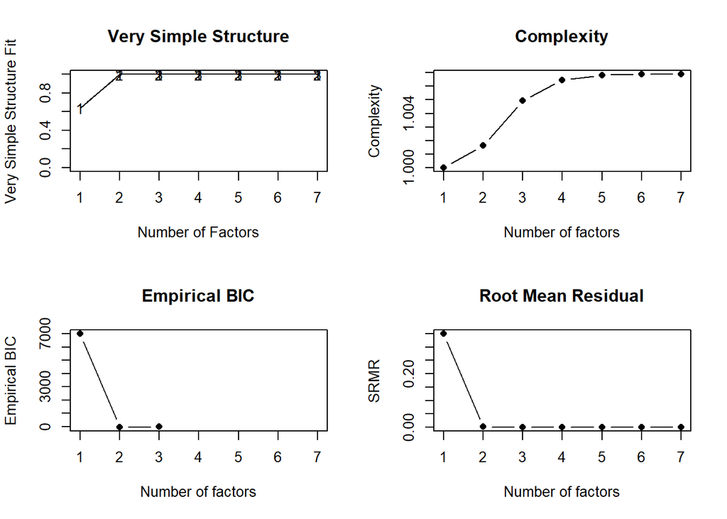

```
##
## Number of factors
## Call: vss(x = x, n = n, rotate = rotate, diagonal = diagonal, fm = fm,
##     n.obs = n.obs, plot = FALSE, title = title, use = use, cor = cor)
## VSS complexity 1 achieves a maximimum of 1  with  6  factors
## VSS complexity 2 achieves a maximimum of 1  with  2  factors
## The Velicer MAP achieves a minimum of 0.07  with  2  factors
## Empirical BIC achieves a minimum of  -57.78  with  2  factors
## Sample Size adjusted BIC achieves a minimum of  -24.88  with  2  factors
##
## Statistics by number of factors
##   vss1 vss2  map dof   chisq prob sqresid  fit RMSEA  BIC SABIC complex
## 1 0.64    0 0.16  14 5.8e+03 0.00   8.156 0.64  0.55 5714  5758       1
## 2 1.00    1 0.07   8 7.6e+00 0.48   0.040 1.00  0.00  -50   -25       1
## 3 1.00    1 0.15   3 5.1e-01 0.92   0.037 1.00  0.00  -21   -12       1
## 4 1.00    1 0.24  -1 4.1e-03   NA   0.037 1.00    NA   NA    NA       1
## 5 1.00    1 0.43  -4 1.3e-04   NA   0.036 1.00    NA   NA    NA       1
## 6 1.00    1 1.00  -6 2.5e-10   NA   0.036 1.00    NA   NA    NA       1
## 7 1.00    1   NA  -7 2.5e-10   NA   0.036 1.00    NA   NA    NA       1
##    eChisq    SRMR   eCRMS eBIC
## 1 7.1e+03 3.5e-01 0.42830 7008
## 2 8.5e-02 1.2e-03 0.00196  -58
## 3 4.7e-03 2.8e-04 0.00075  -22
## 4 3.9e-05 2.6e-05      NA   NA
## 5 1.4e-06 5.0e-06      NA   NA
## 6 2.3e-12 6.3e-09      NA   NA
## 7 2.3e-12 6.3e-09      NA   NA
```

```r
week4 %>%
  select(-id) %>%
  nfactors(.)
```

After looking at everything, it appears that many of our statistics would suggest going with a two factor solution.

If we look at the names of the variables, we can hopefully start to have some thoughts as to how the items might be grouping together.

```r
names(week4)
```

```
## [1] "id"                 "jobTasksSDSA"       "jobBalanceSDSA"
## [4] "jobPaySDSA"         "jobRecognitionSDSA" "jobAdvancementSDSA"
## [7] "jobCoworkersSDSA"   "jobManagementSDSA"
```

We can also take a very quick exploratory look:

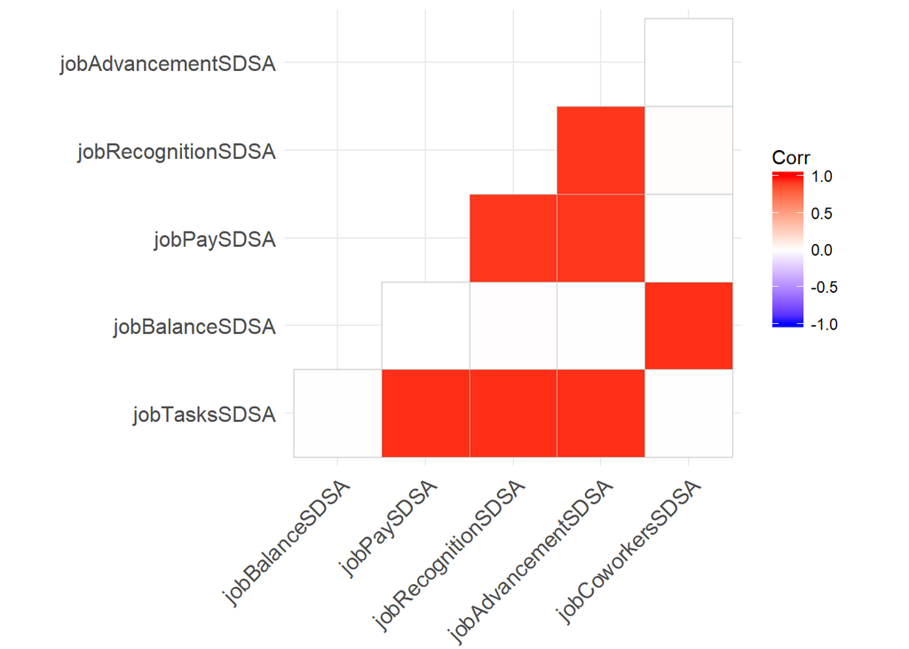

```r
week4 %>%
  select(-id) %>%
  cor() %>%
  ggcorrplot(type = "lower")
```

Before we actually run our analyses, we need to give some serious thought to the factors that might emerge…will the two factors be correlated? If you imagine that the two factors would be correlated, then we need to specify a certain form of rotation. If you don’t think they would be correlated by nature, then the rotation family will change.

Now, we need to think about another issue: the responses. When we looked at the summary (you looked at the summary, right), we could see that these were likely seven point Likert response options (strongly disagree to strongly agree). You will run into a few camps: those who will say that you can treat those numbers, those who demand that they are treated as ordered factors, and those that will say that they are nominal at absolute best. I will leave the nominal folks to ramble on about their nonsense, but I really prefer to mediate piece between the two other camps. There are smart people on both sides who will gladly cross over to champion the others. Since this is a seven point scale, I would not have too many quams with just treating them as numeric. If we were dealing with less, we would want to go the ordinal route.

Now, let’s see some results. We are going to need to drop our id variable here too:

```r
week4FA = week4 %>%
  select(-id) %>%
  fa(., nfactors = 2, rotate = "promax")

week4FA
```

```
## Factor Analysis using method =  minres
## Call: fa(r = ., nfactors = 2, rotate = "promax")
## Standardized loadings (pattern matrix) based upon correlation matrix
##                      MR1   MR2   h2    u2 com
## jobTasksSDSA        0.98  0.00 0.96 0.044   1
## jobBalanceSDSA      0.01  0.98 0.96 0.038   1
## jobPaySDSA          0.96  0.00 0.92 0.080   1
## jobRecognitionSDSA  0.96  0.01 0.92 0.079   1
## jobAdvancementSDSA  0.96 -0.01 0.92 0.080   1
## jobCoworkersSDSA    0.01  0.96 0.91 0.087   1
## jobManagementSDSA  -0.02  0.95 0.90 0.098   1
##
##                        MR1  MR2
## SS loadings           3.72 2.78
## Proportion Var        0.53 0.40
## Cumulative Var        0.53 0.93
## Proportion Explained  0.57 0.43
## Cumulative Proportion 0.57 1.00
##
##  With factor correlations of
##       MR1   MR2
## MR1  1.00 -0.01
## MR2 -0.01  1.00
##
## Mean item complexity =  1
## Test of the hypothesis that 2 factors are sufficient.
##
## The degrees of freedom for the null model are  21  and the objective function was  10.86 with Chi Square of  14990.89
## The degrees of freedom for the model are 8  and the objective function was  0.01
##
## The root mean square of the residuals (RMSR) is  0
## The df corrected root mean square of the residuals is  0
##
## The harmonic number of observations is  1321 with the empirical chi square  0.08  with prob <  1
## The total number of observations was  1384  with Likelihood Chi Square =  7.57  with prob <  0.48
##
## Tucker Lewis Index of factoring reliability =  1
## RMSEA index =  0  and the 90 % confidence intervals are  0 0.03
## BIC =  -50.3
## Fit based upon off diagonal values = 1
## Measures of factor score adequacy
##                                                    MR1  MR2
## Correlation of (regression) scores with factors   0.99 0.99
## Multiple R square of scores with factors          0.98 0.98
## Minimum correlation of possible factor scores     0.97 0.96
```

We lost some observations due to missingness, but our results look really nice! The first thing you should see is the loadings matrix. We can focus our attention on MR1 and MR2. It looks like Tasks, Pay, Recognition, and Advancement load onto one factor, while Balance, Coworkers, and Management load onto another. This seems like we are hitting into a construct that is measuring the actual job (tasks, pay, etc.) and another that is measuring the interpersonal part of the job.

Despite using an oblique rotation, we do not have any correlations between our two factors. I would contend that they should be allowed to correlate.

Let’s see how the factor scores correlate:

```r
week4FA$score.cor
```

```
##              [,1]         [,2]
## [1,]  1.000000000 -0.007583169
## [2,] -0.007583169  1.000000000
```

Let’s just make an assumption that these are two unidimensional constructs. To appease a certain crowd, we need to check on reliability (Cronbach’s $\alpha$, in this case):

```r
week4 %>%
  select(jobTasksSDSA, jobPaySDSA,
         jobRecognitionSDSA, jobAdvancementSDSA) %>%
  psych::alpha()
```

```
##
## Reliability analysis
## Call: psych::alpha(x = .)
##
##   raw_alpha std.alpha G6(smc) average_r S/N     ase mean  sd
##       0.98      0.98    0.98      0.93  52 0.00083  4.9 1.8
##
##  lower alpha upper     95% confidence boundaries
## 0.98 0.98 0.98
##
##  Reliability if an item is dropped:
##                    raw_alpha std.alpha G6(smc) average_r S/N alpha se
## jobTasksSDSA            0.97      0.97    0.96      0.92  35   0.0013
## jobPaySDSA              0.97      0.98    0.97      0.93  41   0.0011
## jobRecognitionSDSA      0.97      0.98    0.97      0.93  41   0.0011
## jobAdvancementSDSA      0.97      0.98    0.97      0.93  41   0.0011
##
##  Item statistics
##                       n raw.r std.r r.cor r.drop mean  sd
## jobTasksSDSA       1384  0.98  0.98  0.97   0.96  4.0 2.0
## jobPaySDSA         1384  0.97  0.97  0.96   0.95  5.2 1.7
## jobRecognitionSDSA 1384  0.97  0.97  0.96   0.95  5.2 1.7
## jobAdvancementSDSA 1384  0.97  0.97  0.96   0.95  5.2 1.7
##
## Non missing response frequency for each item
##                       1    2    3    4    5    6    7 miss
## jobTasksSDSA       0.15 0.14 0.14 0.14 0.14 0.13 0.16    0
## jobPaySDSA         0.00 0.07 0.16 0.13 0.13 0.15 0.35    0
## jobRecognitionSDSA 0.01 0.08 0.14 0.15 0.14 0.15 0.35    0
## jobAdvancementSDSA 0.00 0.07 0.14 0.14 0.15 0.12 0.37    0
```

That one is solid!

```r
week4 %>%
  select(jobBalanceSDSA, jobCoworkersSDSA,
         jobManagementSDSA) %>%
  psych::alpha()
```

```
##
## Reliability analysis
## Call: psych::alpha(x = .)
##
##   raw_alpha std.alpha G6(smc) average_r S/N    ase mean  sd
##       0.97      0.98    0.96      0.93  40 0.0012  4.8 1.7
##
##  lower alpha upper     95% confidence boundaries
## 0.97 0.97 0.97
##
##  Reliability if an item is dropped:
##                   raw_alpha std.alpha G6(smc) average_r S/N alpha se
## jobBalanceSDSA         0.96      0.96    0.92      0.92  22   0.0023
## jobCoworkersSDSA       0.96      0.97    0.93      0.93  28   0.0020
## jobManagementSDSA      0.96      0.97    0.94      0.94  30   0.0019
##
##  Item statistics
##                      n raw.r std.r r.cor r.drop mean  sd
## jobBalanceSDSA    1384  0.98  0.98  0.97   0.96  4.1 2.0
## jobCoworkersSDSA  1384  0.97  0.97  0.96   0.94  5.3 1.7
## jobManagementSDSA 1172  0.97  0.97  0.95   0.94  5.2 1.7
##
## Non missing response frequency for each item
##                   0    1    2    3    4    5    6    7 miss
## jobBalanceSDSA    0 0.13 0.14 0.15 0.15 0.14 0.15 0.15 0.00
## jobCoworkersSDSA  0 0.00 0.07 0.13 0.14 0.16 0.13 0.37 0.00
## jobManagementSDSA 0 0.00 0.06 0.16 0.14 0.15 0.14 0.34 0.15
```

And so is that one. For most practical applications, an $\alpha$ above .7 is going to work for most anyone. Keep in mind, though, that alpha is only appropriate for unidimensional constructs – even then it has some issues.

Just for giggles, let’s try it in an ordinal fashion:

```r
week4FAPoly = week4 %>%
  select(-id) %>%
  fa(., nfactors = 2, rotate = "promax", cor = "poly")
```

After doing all of this work, we definitely want to keep our factor scores.

```r
week4 = week4 %>%
  mutate(factor1Score = week4FA$scores[, "MR1"],
         factor2Score = week4FA$scores[, "MR2"])

summary(week4)
```

```
##       id             jobTasksSDSA   jobBalanceSDSA    jobPaySDSA
##  Length:1384        Min.   :1.000   Min.   :1.000   Min.   :1.000
##  Class :character   1st Qu.:2.000   1st Qu.:2.000   1st Qu.:4.000
##  Mode  :character   Median :4.000   Median :4.000   Median :6.000
##                     Mean   :4.004   Mean   :4.069   Mean   :5.178
##                     3rd Qu.:6.000   3rd Qu.:6.000   3rd Qu.:7.000
##                     Max.   :7.000   Max.   :7.000   Max.   :7.000
##
##  jobRecognitionSDSA jobAdvancementSDSA jobCoworkersSDSA jobManagementSDSA
##  Min.   :1.000      Min.   :1.00       Min.   :1.000    Min.   :0.000
##  1st Qu.:4.000      1st Qu.:4.00       1st Qu.:4.000    1st Qu.:4.000
##  Median :5.000      Median :5.00       Median :6.000    Median :5.000
##  Mean   :5.173      Mean   :5.21       Mean   :5.259    Mean   :5.174
##  3rd Qu.:7.000      3rd Qu.:7.00       3rd Qu.:7.000    3rd Qu.:7.000
##  Max.   :7.000      Max.   :7.00       Max.   :7.000    Max.   :7.000
##                                                         NA's   :212
##   factor1Score       factor2Score
##  Min.   :-1.85230   Min.   :-1.98031
##  1st Qu.:-1.05405   1st Qu.:-1.02366
##  Median :-0.06863   Median : 0.04607
##  Mean   :-0.10957   Mean   :-0.03625
##  3rd Qu.: 0.91657   3rd Qu.: 1.01495
##  Max.   : 1.23033   Max.   : 1.31106
##  NA's   :212        NA's   :212
```

We will be able to use these scores in models or anything else that we want.

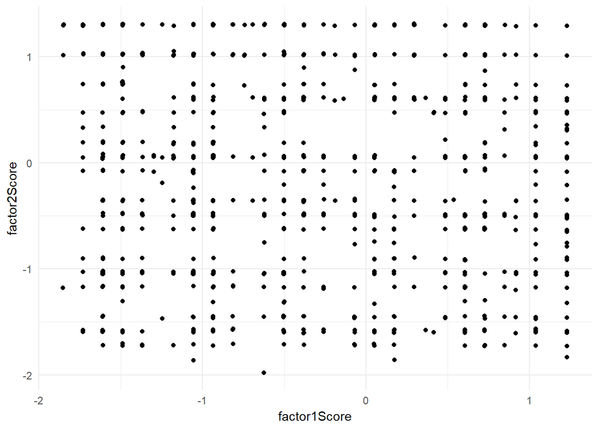

```r
ggplot(week4, aes(factor1Score, factor2Score)) +
  geom_point() +
  theme_minimal()
```

Not much happening there!